# 통계 방법론1 part1

응용통계학과 이준혁

2023-10-14(토)

# 4. 단순 회귀 분석 Simple Regression Analysis

## 4.1. 회귀 계수의 추정: 최소 제곱법(Method of Least Squares)

## 4.2. 잔차 residuals

## 4.3. 변동의 분해 decompostion of variations

## 4.4. 회귀 계수의 유의성 검정

## 실습 17.. simple.csv: 임의로 선택된 소형 화물의 무게$(x;~g)$과 부피$(y;~cm^3)$

- 예제1 simple.csv
- 무게에 의하여 운송 요금을 결정하는 소형 화물들 중에서 임의로 선택된 58개의 무게(x; weight)과 부피(y; volume)을 조사하였다.
- 이를 이용하여 중량과 부피간의 관계를 추정하여 운송 계획을 수립하고자 한다.

```r
cargo <- read.csv(paste0(data_path, "simple.csv"))
str(cargo)
```

```
## 'data.frame':    58 obs. of  3 variables:
##  $ x : num  80.9 84.2 127.2 78.9 95.5 ...
##  $ y : num  2070 2799 4021 2496 2478 ...
##  $ hy: num  2358 2465 3824 2295 2820 ...
```

```r
na_count <- function(df){
  sapply(df, function(y) sum(length(which(is.na(y)))))
}

na_count(cargo)
```

```
##  x  y hy
##  0  0  0
```

```r
x <- cargo$x
y <- cargo$y
Sxy <- sum((x - mean(x)) * (y - mean(y)))
Sxx <- sum((x - mean(x))^2)
Syy <- sum((y - mean(y))^2)
#
hat_beta1 <- Sxy / Sxx
hat_beta0 <- mean(y) - hat_beta1*mean(x)
round(c(hat_beta0, hat_beta1), 2)
```

```
## [1] -204.1   31.7
```

## 실습 18. 유통 매장 정리 시간, dist.store.csv

- 데이터 불러오기

```r
dist <- read.csv(paste0(data_path, "dist.store.csv"))
```

- 데이터 확인

```r
str(dist)
```

```
## 'data.frame':    25 obs. of  3 variables:
##  $ Time    : num  16.7 11.5 12 14.9 13.8 ...
##  $ Case    : int  7 3 3 4 6 7 2 7 30 5 ...
##  $ distance: int  280 110 170 40 75 165 55 105 730 302 ...
```

```r
head(dist)
```

```
##   Time Case distance
## 1 16.7    7      280
## 2 11.5    3      110
## 3 12.0    3      170
## 4 14.9    4       40
## 5 13.8    6       75
## 6 18.1    7      165
```

```r
tail(dist)
```

```
##    Time Case distance
## 20 35.1   17      385
## 21 17.9   10       70
## 22 52.3   26      405
## 23 18.8    9      225
## 24 19.8    8      318
## 25 10.8    4       75
```

```r
view(dist)
```

```r
dist <- dist %>%
  rename_all(tolower)

head(dist, 5)
```

```
##   time case distance
## 1 16.7    7      280
## 2 11.5    3      110
## 3 12.0    3      170
## 4 14.9    4       40
## 5 13.8    6       75
```

```r
na_count <- function(df){
  sapply(df, function(y) sum(length(which(is.na(y)))))
}

na_count(dist)
```

```
##     time     case distance
##        0        0        0
```

- 시각화: 관계의 검토

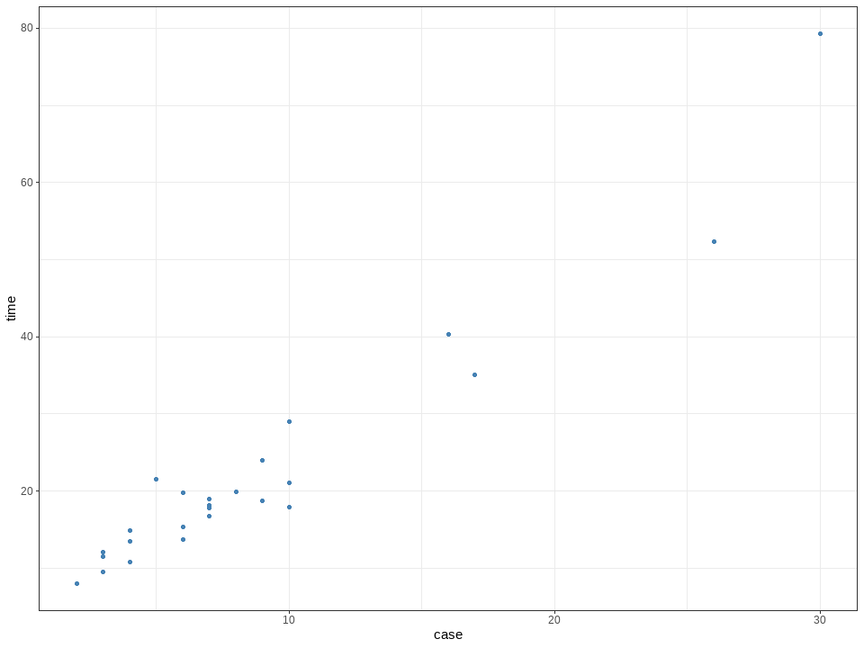

```r
dist %>%
  ggplot(aes(case, time)) +
  geom_point(color = sbl) +
  theme_bw()
```

- (case, time)의 관계는 직선의 경향을 갖는다.
- 회귀 분석의 실행

```r
dist_fit <- lm(time ~ case, data = dist)
```

- 분석 결과 확인

```r
summary(dist_fit)
```

```
##
## Call:
## lm(formula = time ~ case, data = dist)
##
## Residuals:
##    Min     1Q Median     3Q    Max
## -7.581 -1.874 -0.349  2.181 10.634
##
## Coefficients:
##             Estimate Std. Error t value           Pr(>|t|)
## (Intercept)    3.321      1.371    2.42              0.024 *
## case           2.176      0.124   17.55 0.0000000000000082 ***
## ---
## Signif. codes:  0 '***' 0.001 '**' 0.01 '*' 0.05 '.' 0.1 ' ' 1
##
## Residual standard error: 4.18 on 23 degrees of freedom
## Multiple R-squared:  0.93,   Adjusted R-squared:  0.927
## F-statistic:  308 on 1 and 23 DF,  p-value: 0.00000000000000822
```

## 실습 19. Test Case Determination, test.sw.csv

# 5. 다중 회귀 분석 Multiple Regression Analysis

## 5.1. 최소 제곱법과 중요 결과

## 5.2. 변수 선택 Variable Selection

### 5.2.1. 전방 선택 Foreward Selection

### 5.2.2. 후방 제거 Backward Elimination

### 5.2.3. 단계별 선택 Stepwise Selection

### 5.2.4. 모든 부분 집합

## 실습 20. C-materials, cem.materials.csv

- 데이터 불러오기

```r
cem <- read.csv(paste0(data_path,"cem.materials.csv"))
str(cem)
```

```
## 'data.frame':    13 obs. of  6 variables:
##  $ ID: int  1 2 3 4 5 6 7 8 9 10 ...
##  $ T1: int  7 1 11 11 7 11 3 1 2 21 ...
##  $ T2: int  26 29 56 31 52 55 71 31 54 47 ...
##  $ T3: int  6 15 8 8 6 9 17 22 18 4 ...
##  $ T4: int  60 52 20 47 33 22 6 44 22 26 ...
##  $ Y : num  78.5 74.3 104.3 87.6 95.9 ...
```

- 변수 이름과 위치 정리

```r
cem <- cem %>%
  dplyr::rename_all(tolower) %>%
  select(-id) %>%
  relocate(y)
```

- 결측값 확인

```r
na_count <- function(data){
  sapply(data, function(y) sum(length(which(is.na(y)))))
}
```

```r
na_count(cem)
```

```
##  y t1 t2 t3 t4
##  0  0  0  0  0
```

- 데이터 시각화: 행렬도(matrix plot)

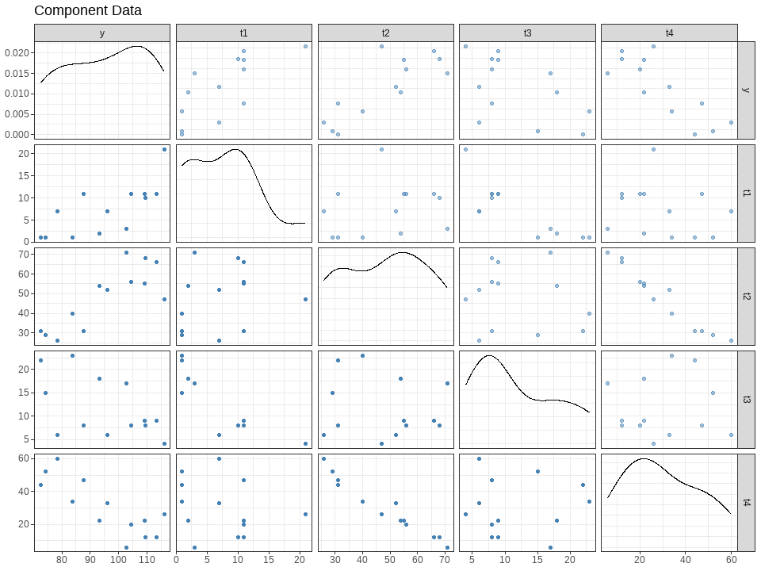

```r
cem %>%
  ggpairs(columns = 1:ncol(.),
          lower = list(continuous = wrap("points", # continuous = "smooth"
                                         color = sbl,
                                         aplha = 0.5)
                   ),
          upper = list(continuous = wrap("points", # wrap("cor", size = 2.5)
                                         color = sbl,
                                         alpha =0.5)
                   ),
          diag = list(continuous = wrap("densityDiag",
                                        color = "black",
                                        alpha = 0.5)
                   ),
          title = "Component Data") +
  theme_bw()
```

- 함수 정의
  - 원하는 형태의 행렬도(matrix plot) 형식을 결정하여 함수화

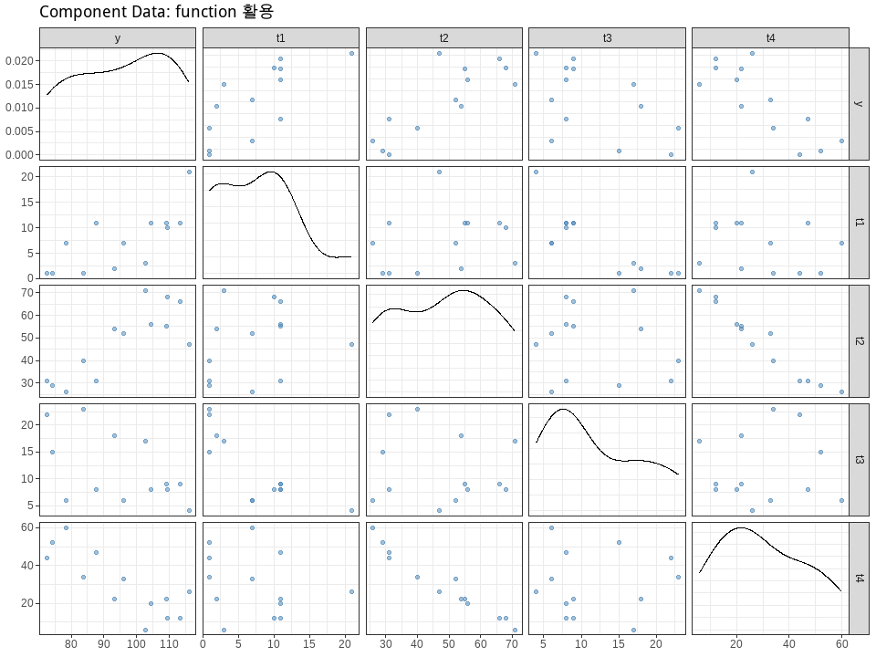

```r
gg_mplot <- function(df, ttl){
  df %>%
  ggpairs(columns = 1:ncol(.),
          lower = list(continuous = wrap("points", #continuous = "smooth"
                                         color = sbl,
                                         alpha = 0.5)
                       ),
          upper = list(continuous = wrap("points", #wrap("cor", size = 2.5)
                                         color = sbl,
                                         alpha = 0.5)
                       ),
          diag = list(continuous = wrap("densityDiag",
                                        color = "black",
                                        alpha = 0.5)
                       ),
          title = ttl) +
  theme_bw()
}

ttl = "Component Data: function 활용"
gg_mplot(cem, ttl)
```

- 다중 회귀 분석: lm()
  - lm() 함수는 단순 회귀 분석과 동일하게 적용된다.
  - 단, formula를 사전에 지정하는 경우에는 문자형으로 정의되어야 한다.

```r
fml <- "y ~ t1 + t2 + t3 + t4"
cem_model <- lm(fml, cem)
summary(cem_model)
```

```
##
## Call:
## lm(formula = fml, data = cem)
##
## Residuals:
##    Min     1Q Median     3Q    Max
## -3.175 -1.671  0.251  1.378  3.925
##
## Coefficients:
##             Estimate Std. Error t value Pr(>|t|)
## (Intercept)   62.405     70.071    0.89    0.399
## t1             1.551      0.745    2.08    0.071 .
## t2             0.510      0.724    0.70    0.501
## t3             0.102      0.755    0.14    0.896
## t4            -0.144      0.709   -0.20    0.844
## ---
## Signif. codes:  0 '***' 0.001 '**' 0.01 '*' 0.05 '.' 0.1 ' ' 1
##
## Residual standard error: 2.45 on 8 degrees of freedom
## Multiple R-squared:  0.982,  Adjusted R-squared:  0.974
## F-statistic:  111 on 4 and 8 DF,  p-value: 0.000000476
```

- 구간 추정
  - lm()에 의한 model object가 생성

```r
confint(cem_model, level = 0.95)
```

```
##               2.5 % 97.5 %
## (Intercept) -99.179 223.99
## t1           -0.166   3.27
## t2           -1.159   2.18
## t3           -1.638   1.84
## t4           -1.779   1.49
```

```r
confint(cem_model, c("t1", "t2"), level = 0.95)
```

```
##     2.5 % 97.5 %
## t1 -0.166   3.27
## t2 -1.159   2.18
```

- 가설 검정
  - lm()을 적용한 model object의 summary()의 coef를 부분 선택

```r
summary(cem_model)$coef
```

```
##             Estimate Std. Error t value Pr(>|t|)
## (Intercept)   62.405     70.071   0.891   0.3991
## t1             1.551      0.745   2.083   0.0708
## t2             0.510      0.724   0.705   0.5009
## t3             0.102      0.755   0.135   0.8959
## t4            -0.144      0.709  -0.203   0.8441
```

- 예측 구간